# CPE232: Data Models

### Portion 2: Midterm Exam Coding

Sections: A, B, RC

```python
# Run this cell if using Google Colab
from google.colab import drive
drive.mount('/content/drive')
```

ข้อมูลในชุดข้อมูล student_spending.csv ที่ให้มาประกอบด้วยข้อมูลที่เกี่ยวข้องกับการใช้จ่ายของนักเรียน ภารกิจของคุณคือการทำการวิเคราะห์ข้อมูลเชิงสำรวจ (EDA) ตามภารกิจย่อยห้าประการดังต่อไปนี้

### Subtask #1: รู้จักกับชุดข้อมูล

#### 1.1) ศึกษาภาพรวมของชุดข้อมูล (Total points = 3)

[3 points] Display information of the data: size, shape, and number of dimensions. You can use any libraries of your choice (e.g. Numpy, Pandas).

แสดงรายละเอียดต่อไปนี้ของชุดข้อมูล: ขนาด, รูปร่าง, และจำนวนมิติ นักศึกษาสามารถใช้ไลบรารีใดก็ได้ตามต้องการ (เช่น Numpy, Pandas)

```python
import pandas as pd
df = pd.read_csv('student_spending.csv') #TODO: update the path and filename at this line
```

```python
# Write your code here
print(df.size)
print(df.shape)
print(df.ndim)
```

```
18000
(1000, 18)
2
```

#### 1.2) ศึกษาสถิติของชุดข้อมูลนี้เพิ่มเติม (Total point = 15)

Use the command below:

ใช้คำสั่งต่อไปนี้:

`df.info()`

```python
df.info()
```

```
<class 'pandas.core.frame.DataFrame'>
RangeIndex: 1000 entries, 0 to 999
Data columns (total 18 columns):
 #   Column                    Non-Null Count  Dtype
---  ------                    --------------  -----
 0   Unnamed: 0                1000 non-null   int64
 1   age                       1000 non-null   int64
 2   gender                    1000 non-null   object
 3   year_in_school            1000 non-null   object
 4   major                     1000 non-null   object
 5   monthly_income            1000 non-null   int64
 6   financial_aid             1000 non-null   int64
 7   tuition                   1000 non-null   int64
 8   housing                   1000 non-null   int64
 9   food                      1000 non-null   int64
 10  transportation            1000 non-null   int64
 11  books_supplies            1000 non-null   int64
 12  entertainment             1000 non-null   int64
 13  personal_care             1000 non-null   int64
 14  technology                1000 non-null   int64
 15  health_wellness           1000 non-null   int64
 16  miscellaneous             1000 non-null   int64
 17  preferred_payment_method  1000 non-null   object
dtypes: int64(14), object(4)
memory usage: 140.8+ KB
```

[2 points] Obtain the following information and provide your answers:

- Number of columns of the type *Integer*
- Number of columns of the type *String*

หาค่าต่อไปนี้จากชุดข้อมูลและระบุคำตอบ:

- จำนวนคอลัมน์ที่เป็น *Integer*
- จำนวนคอลัมน์ที่เป็น *String*

**ANS:**

- จำนวนคอลัมน์ที่เป็น *Integer* : 14
- จำนวนคอลัมน์ที่เป็น *String* : 4

[1 point] Display the first 6 rows.

แสดง 6 แถวแรกของข้อมูล

```python
# Write your code here
df.head(6)
```

|  | Unnamed: 0 | age | gender | year_in_school | major | monthly_income | financial_aid | tuition | housing | food | transportation | books_supplies | entertainment | personal_care | technology | health_wellness | miscellaneous | preferred_payment_method |
| --- | --- | --- | --- | --- | --- | --- | --- | --- | --- | --- | --- | --- | --- | --- | --- | --- | --- | --- |
| 0 | 0 | 19 | Non-binary | Freshman | Psychology | 958 | 270 | 5939 | 709 | 296 | 123 | 188 | 41 | 78 | 134 | 127 | 72 | Credit/Debit Card |
| 1 | 1 | 24 | Female | Junior | Economics | 1006 | 875 | 4908 | 557 | 365 | 85 | 252 | 74 | 92 | 226 | 129 | 68 | Credit/Debit Card |
| 2 | 2 | 24 | Non-binary | Junior | Economics | 734 | 928 | 3051 | 666 | 220 | 137 | 99 | 130 | 23 | 239 | 112 | 133 | Cash |
| 3 | 3 | 23 | Female | Senior | Computer Science | 617 | 265 | 4935 | 652 | 289 | 114 | 223 | 99 | 30 | 163 | 105 | 55 | Mobile Payment App |
| 4 | 4 | 20 | Female | Senior | Computer Science | 810 | 522 | 3887 | 825 | 372 | 168 | 194 | 48 | 71 | 88 | 71 | 104 | Credit/Debit Card |
| 5 | 5 | 25 | Non-binary | Sophomore | Computer Science | 523 | 790 | 3151 | 413 | 386 | 122 | 131 | 73 | 38 | 234 | 108 | 99 | Mobile Payment App |

[1 point] Display the last 10 rows.

แสดง 10 แถวสุดท้ายของข้อมูล

```python
# Write your code here
df.tail(10)
```

|  | Unnamed: 0 | age | gender | year_in_school | major | monthly_income | financial_aid | tuition | housing | food | transportation | books_supplies | entertainment | personal_care | technology | health_wellness | miscellaneous | preferred_payment_method |
| --- | --- | --- | --- | --- | --- | --- | --- | --- | --- | --- | --- | --- | --- | --- | --- | --- | --- | --- |
| 990 | 990 | 20 | Non-binary | Senior | Psychology | 1412 | 155 | 5576 | 443 | 305 | 119 | 136 | 120 | 41 | 290 | 30 | 91 | Mobile Payment App |
| 991 | 991 | 24 | Non-binary | Junior | Psychology | 1391 | 259 | 3572 | 755 | 136 | 55 | 86 | 62 | 66 | 187 | 153 | 23 | Cash |
| 992 | 992 | 20 | Male | Freshman | Economics | 1293 | 672 | 5635 | 435 | 389 | 192 | 87 | 23 | 64 | 67 | 77 | 137 | Credit/Debit Card |
| 993 | 993 | 20 | Male | Freshman | Psychology | 1380 | 594 | 3658 | 739 | 277 | 187 | 92 | 144 | 69 | 283 | 68 | 21 | Mobile Payment App |
| 994 | 994 | 22 | Male | Senior | Psychology | 764 | 286 | 5430 | 589 | 387 | 61 | 68 | 46 | 96 | 86 | 46 | 85 | Mobile Payment App |
| 995 | 995 | 22 | Female | Senior | Biology | 1346 | 520 | 3688 | 969 | 152 | 194 | 151 | 42 | 38 | 252 | 65 | 163 | Cash |
| 996 | 996 | 19 | Female | Senior | Biology | 1407 | 560 | 3380 | 508 | 265 | 52 | 206 | 40 | 98 | 274 | 84 | 135 | Mobile Payment App |
| 997 | 997 | 20 | Male | Junior | Economics | 957 | 393 | 3497 | 723 | 339 | 139 | 69 | 112 | 46 | 284 | 57 | 28 | Mobile Payment App |
| 998 | 998 | 22 | Non-binary | Senior | Economics | 1174 | 612 | 3649 | 543 | 237 | 123 | 200 | 129 | 90 | 190 | 101 | 65 | Mobile Payment App |
| 999 | 999 | 24 | Non-binary | Sophomore | Computer Science | 541 | 640 | 5965 | 609 | 270 | 191 | 215 | 139 | 43 | 281 | 88 | 145 | Cash |

[1 point] Descriptive statistics of *ALL attributes*

สถิติเชิงพรรณนาของ *ทุกๆคุณลักษณะ*

```python
# Write your code here
df.describe()
```

|  | Unnamed: 0 | age | monthly_income | financial_aid | tuition | housing | food | transportation | books_supplies | entertainment | personal_care | technology | health_wellness | miscellaneous |
| --- | --- | --- | --- | --- | --- | --- | --- | --- | --- | --- | --- | --- | --- | --- |
| count | 1000.000000 | 1000.000000 | 1000.000000 | 1000.000000 | 1000.000000 | 1000.00000 | 1000.000000 | 1000.00000 | 1000.000000 | 1000.000000 | 1000.000000 | 1000.000000 | 1000.000000 | 1000.000000 |
| mean | 499.500000 | 21.675000 | 1020.650000 | 504.771000 | 4520.395000 | 696.00600 | 252.642000 | 124.63700 | 174.761000 | 84.814000 | 60.699000 | 178.304000 | 114.310000 | 108.910000 |
| std | 288.819436 | 2.322664 | 293.841161 | 287.092575 | 860.657944 | 171.21862 | 86.949606 | 43.55799 | 72.404518 | 37.970451 | 22.898007 | 71.744441 | 49.591544 | 52.412221 |
| min | 0.000000 | 18.000000 | 501.000000 | 0.000000 | 3003.000000 | 401.00000 | 100.000000 | 50.00000 | 50.000000 | 20.000000 | 20.000000 | 50.000000 | 30.000000 | 20.000000 |
| 25% | 249.750000 | 20.000000 | 770.750000 | 261.000000 | 3779.750000 | 538.75000 | 175.000000 | 88.00000 | 112.000000 | 54.000000 | 41.000000 | 114.000000 | 73.000000 | 63.750000 |
| 50% | 499.500000 | 22.000000 | 1021.000000 | 513.000000 | 4547.500000 | 704.50000 | 255.000000 | 123.00000 | 175.000000 | 86.000000 | 62.000000 | 178.000000 | 115.000000 | 110.000000 |
| 75% | 749.250000 | 24.000000 | 1288.250000 | 751.500000 | 5285.000000 | 837.25000 | 330.000000 | 162.25000 | 238.000000 | 116.000000 | 80.000000 | 241.000000 | 158.000000 | 153.000000 |
| max | 999.000000 | 25.000000 | 1500.000000 | 1000.000000 | 6000.000000 | 1000.00000 | 400.000000 | 200.00000 | 300.000000 | 150.000000 | 100.000000 | 300.000000 | 200.000000 | 200.000000 |

[1 point] Descriptive statistics of *one selected attribute*: `tuition`

สถิติเชิงพรรณนาของ *หนึ่งคุณลักษณะ*: `tuition`

```python
# Write your code here
df['tuition'].describe()
```

```
count    1000.000000
mean     4520.395000
std       860.657944
min      3003.000000
25%      3779.750000
50%      4547.500000
75%      5285.000000
max      6000.000000
Name: tuition, dtype: float64
```

[4 points] Descriptive statistics of *four selected attribute*: `age`, `housing`, `food`, `transportation`

สถิติเชิงพรรณนาของ *สี่คุณลักษณะ*: `age`, `housing`, `food`, `transportation`

```python
# Write your code here
df[['age', 'housing', 'food', 'transportation']].describe()
```

|  | age | housing | food | transportation |
| --- | --- | --- | --- | --- |
| count | 1000.000000 | 1000.00000 | 1000.000000 | 1000.00000 |
| mean | 21.675000 | 696.00600 | 252.642000 | 124.63700 |
| std | 2.322664 | 171.21862 | 86.949606 | 43.55799 |
| min | 18.000000 | 401.00000 | 100.000000 | 50.00000 |
| 25% | 20.000000 | 538.75000 | 175.000000 | 88.00000 |
| 50% | 22.000000 | 704.50000 | 255.000000 | 123.00000 |
| 75% | 24.000000 | 837.25000 | 330.000000 | 162.25000 |
| max | 25.000000 | 1000.00000 | 400.000000 | 200.00000 |

[5 points] Display the number of occurrences of each unique value in ALL *non-integer* columns.

แสดงจำนวนครั้งที่แต่ละค่าที่ไม่ซ้ำกันปรากฏในทุกคอลัมน์ที่ *ไม่ใช่จำนวนเต็ม*

*Hint: Example of the output may look like the following for the column named `genre`.*

*ตัวอย่างของผลลัพธ์อาจคล้ายผลต่อไปนี้สำหรับคอลัมน์ที่มีชื่อว่า `genre`*

```
genre
pop         550
jazz        234
rock        294
country     146
Name: count, dtype: int64
```

```python
# Write your code here
# gender
print(df['gender'].unique())
print('Non-binary',(df[df['gender'] == 'Non-binary'].count().sum())/17)
print('Female',(df[df['gender'] == 'Female'].count().sum())/17)
print('Male',(df[df['gender'] == 'Male'].count().sum())/17)
print('dtype: int64')
```

```
['Non-binary' 'Female' 'Male']
Non-binary 321.0
Female 323.0
Male 356.0
dtype: int64
```

```python
# year_in_school
print(df['year_in_school'].unique())
print('Freshman',(df[df['year_in_school'] == 'Freshman'].count().sum())/17)
print('Junior',(df[df['year_in_school'] == 'Junior'].count().sum())/17)
print('Senior',(df[df['year_in_school'] == 'Senior'].count().sum())/17)
print('Sophomore',(df[df['year_in_school'] == 'Sophomore'].count().sum())/17)
print('dtype: int64')
```

```
['Freshman' 'Junior' 'Senior' 'Sophomore']
Freshman 253.0
Junior 247.0
Senior 254.0
Sophomore 246.0
dtype: int64
```

```python
# major
print(df['major'].unique())
print('Psychology',(df[df['major'] == 'Psychology'].count().sum())/17)
print('Economics',(df[df['major'] == 'Economics'].count().sum())/17)
print('Computer Science', (df[df['major'] == 'Computer Science'].count().sum())/17)
print('Engineering', (df[df['major'] == 'Engineering'].count().sum())/17)
print('Biology', (df[df['major'] == 'Biology'].count().sum())/17)
print('dtype: int64')
```

```
['Psychology' 'Economics' 'Computer Science' 'Engineering' 'Biology']
Psychology 184.0
Economics 204.0
Computer Science 192.0
Engineering 192.0
Biology 228.0
dtype: int64
```

```python
# preferred_payment_method
print(df['preferred_payment_method'].unique())
print('Credit/Debit Card',(df[df['preferred_payment_method'] == 'Credit/Debit Card'].count().sum())/17)
print('Cash',(df[df['preferred_payment_method'] == 'Cash'].count().sum())/17)
print('Mobile Payment App',(df[df['preferred_payment_method'] == 'Mobile Payment App'].count().sum())/17)
print('dtype: int64')
```

```
['Credit/Debit Card' 'Cash' 'Mobile Payment App']
Credit/Debit Card 340.0
Cash 310.0
Mobile Payment App 350.0
dtype: int64
```

### Subtask #2: ตรวจสอบข้อมูล

#### 2.1) ตรวจสอบข้อมูลนักศึกษาโดยกำหนดเงื่อนไข (Total points = 14)

[4 points] Display *the first 10 rows* of records that meet the condition: *Students with a major in Computer Science with a spending on technology more than 100.*

แสดง 10 แถวแรก ของข้อมูลที่ตรงตามเงื่อนไขต่อไปนี้: *นักศึกษาที่เรียนสาขาวิทยาการคอมพิวเตอร์และมีค่าใช้จ่ายด้านเทคโนโลยีมากกว่า 100*

```python
# Write your code here
# Students with a major in Computer Science with a spending on technology more than 100.
df[(df['major']=='Computer Science') & (df['technology'] > 100)].head(10)
```

|  | Unnamed: 0 | age | gender | year_in_school | major | monthly_income | financial_aid | tuition | housing | food | transportation | books_supplies | entertainment | personal_care | technology | health_wellness | miscellaneous | preferred_payment_method |
| --- | --- | --- | --- | --- | --- | --- | --- | --- | --- | --- | --- | --- | --- | --- | --- | --- | --- | --- |
| 3 | 3 | 23 | Female | Senior | Computer Science | 617 | 265 | 4935 | 652 | 289 | 114 | 223 | 99 | 30 | 163 | 105 | 55 | Mobile Payment App |
| 5 | 5 | 25 | Non-binary | Sophomore | Computer Science | 523 | 790 | 3151 | 413 | 386 | 122 | 131 | 73 | 38 | 234 | 108 | 99 | Mobile Payment App |
| 8 | 8 | 22 | Non-binary | Senior | Computer Science | 1402 | 248 | 5638 | 599 | 354 | 82 | 155 | 123 | 41 | 162 | 172 | 194 | Credit/Debit Card |
| 9 | 9 | 18 | Female | Junior | Computer Science | 1423 | 74 | 3977 | 626 | 249 | 117 | 123 | 51 | 74 | 243 | 34 | 196 | Mobile Payment App |
| 32 | 32 | 24 | Non-binary | Junior | Computer Science | 522 | 555 | 5236 | 860 | 169 | 133 | 147 | 123 | 48 | 138 | 89 | 150 | Credit/Debit Card |
| 37 | 37 | 23 | Non-binary | Senior | Computer Science | 1309 | 265 | 5160 | 600 | 178 | 148 | 186 | 88 | 78 | 242 | 54 | 172 | Cash |
| 45 | 45 | 18 | Male | Freshman | Computer Science | 929 | 348 | 3854 | 590 | 204 | 196 | 183 | 129 | 80 | 163 | 116 | 55 | Credit/Debit Card |
| 52 | 52 | 19 | Male | Senior | Computer Science | 669 | 660 | 3823 | 837 | 193 | 115 | 75 | 121 | 65 | 150 | 96 | 58 | Cash |
| 56 | 56 | 24 | Non-binary | Freshman | Computer Science | 854 | 700 | 4824 | 525 | 223 | 145 | 133 | 47 | 91 | 294 | 191 | 170 | Cash |
| 71 | 71 | 21 | Non-binary | Sophomore | Computer Science | 1235 | 805 | 5442 | 745 | 390 | 150 | 228 | 96 | 80 | 104 | 35 | 131 | Cash |

มีทั้งหมดจำนวนกี่รายการที่ตรงกับเงื่อนไขข้างต้น?

[8 points] Display *the first 10 rows* of records that meet the condition: *Male Sophomore students with monthly income ranging from 600 to 1000.*

แสดง 10 แถวแรก ของข้อมูลที่ตรงตามเงื่อนไขต่อไปนี้: *นักศึกษาชั้นปีที่สอง (Sophomore) ที่เป็นเพศชายและมีรายได้ต่อเดือนอยู่ในช่วง 600 ถึง 1000*

```python
# Write your code here
# Male Sophomore students with monthly income ranging from 600 to 1000.
df[(df['year_in_school']=='Sophomore') & (df['gender'] == 'Male') & (df['monthly_income'] >= 600) & (df['monthly_income'] <= 1000) ].head(10)
```

|  | Unnamed: 0 | age | gender | year_in_school | major | monthly_income | financial_aid | tuition | housing | food | transportation | books_supplies | entertainment | personal_care | technology | health_wellness | miscellaneous | preferred_payment_method |
| --- | --- | --- | --- | --- | --- | --- | --- | --- | --- | --- | --- | --- | --- | --- | --- | --- | --- | --- |
| 12 | 12 | 21 | Male | Sophomore | Economics | 719 | 540 | 4863 | 894 | 280 | 120 | 126 | 41 | 50 | 78 | 113 | 114 | Credit/Debit Card |
| 41 | 41 | 25 | Male | Sophomore | Economics | 804 | 140 | 5332 | 517 | 289 | 147 | 153 | 125 | 43 | 159 | 44 | 127 | Cash |
| 76 | 76 | 22 | Male | Sophomore | Computer Science | 983 | 862 | 5650 | 648 | 159 | 128 | 259 | 124 | 97 | 96 | 150 | 134 | Cash |
| 89 | 89 | 23 | Male | Sophomore | Economics | 800 | 933 | 5304 | 421 | 144 | 97 | 51 | 103 | 66 | 247 | 183 | 92 | Credit/Debit Card |
| 108 | 108 | 20 | Male | Sophomore | Computer Science | 965 | 322 | 4992 | 433 | 175 | 56 | 71 | 89 | 74 | 66 | 59 | 130 | Mobile Payment App |
| 110 | 110 | 22 | Male | Sophomore | Economics | 970 | 553 | 5894 | 680 | 344 | 156 | 114 | 120 | 79 | 53 | 40 | 156 | Mobile Payment App |
| 126 | 126 | 20 | Male | Sophomore | Biology | 836 | 620 | 4311 | 584 | 301 | 160 | 193 | 91 | 46 | 143 | 120 | 53 | Cash |
| 148 | 148 | 24 | Male | Sophomore | Computer Science | 897 | 220 | 4655 | 799 | 358 | 125 | 290 | 80 | 23 | 156 | 177 | 46 | Credit/Debit Card |
| 157 | 157 | 20 | Male | Sophomore | Economics | 901 | 115 | 3388 | 737 | 295 | 84 | 297 | 66 | 80 | 146 | 100 | 93 | Mobile Payment App |
| 175 | 175 | 23 | Male | Sophomore | Biology | 963 | 871 | 4951 | 778 | 253 | 105 | 135 | 124 | 46 | 185 | 164 | 160 | Cash |

มีทั้งหมดจำนวนกี่รายการที่ตรงกับเงื่อนไขข้างต้น?

#### 2.2) ตรวจสอบว่ามีค่าที่ตกหล่นไปหรือไม่ (Total point = 1)

[1 point] How many attributes contain missing values?

มีคุณลักษณะ (attribute) กี่รายการที่มีค่าที่ตกหล่นไป

**ANS:** ไม่มี missing value

```python
df.isnull().sum()
```

```
Unnamed: 0                  0
age                         0
gender                      0
year_in_school              0
major                       0
monthly_income              0
financial_aid               0
tuition                     0
housing                     0
food                        0
transportation              0
books_supplies              0
entertainment               0
personal_care               0
technology                  0
health_wellness             0
miscellaneous               0
preferred_payment_method    0
dtype: int64
```

### Subtask #3: จัดเตรียมข้อมูล

#### 3.1 ลบคอลัมน์ที่ไม่จำเป็นออกจากชุดข้อมูล (Total points = 2)

[2 points] ลบคอลัมน์ "Unnamed: 0" ออกจากชุดข้อมูล

*(Note: this column must no longer appear when displaying the dataframe again later; หมายเหตุ: คอลัมน์นี้ต้องไม่ปรากฏอีกเมื่อแสดง DataFrame ในภายหลัง)*

```python
# Write your code here
df = df.drop(columns=['Unnamed: 0'])
```

```python
df.head()
```

|  | age | gender | year_in_school | major | monthly_income | financial_aid | tuition | housing | food | transportation | books_supplies | entertainment | personal_care | technology | health_wellness | miscellaneous | preferred_payment_method |
| --- | --- | --- | --- | --- | --- | --- | --- | --- | --- | --- | --- | --- | --- | --- | --- | --- | --- |
| 0 | 19 | Non-binary | Freshman | Psychology | 958 | 270 | 5939 | 709 | 296 | 123 | 188 | 41 | 78 | 134 | 127 | 72 | Credit/Debit Card |
| 1 | 24 | Female | Junior | Economics | 1006 | 875 | 4908 | 557 | 365 | 85 | 252 | 74 | 92 | 226 | 129 | 68 | Credit/Debit Card |
| 2 | 24 | Non-binary | Junior | Economics | 734 | 928 | 3051 | 666 | 220 | 137 | 99 | 130 | 23 | 239 | 112 | 133 | Cash |
| 3 | 23 | Female | Senior | Computer Science | 617 | 265 | 4935 | 652 | 289 | 114 | 223 | 99 | 30 | 163 | 105 | 55 | Mobile Payment App |
| 4 | 20 | Female | Senior | Computer Science | 810 | 522 | 3887 | 825 | 372 | 168 | 194 | 48 | 71 | 88 | 71 | 104 | Credit/Debit Card |

#### 3.2 สร้างคอลัมน์ใหม่ (Total points = 23)

[5 points] Create a new column and name it `major_expense`. This column contains values that are the sum of housing, food, and transportation.

สร้างคอลัมน์ใหม่ชื่อ `major_expense` โดยมีค่าที่ได้จากผลรวมของค่าใช้จ่ายด้านที่อยู่อาศัย อาหาร และการเดินทาง

```python
# Write your code here
df = df.assign(major_expense = df['housing']+df['food']+df['transportation'])
df
```

|  | age | gender | year_in_school | major | monthly_income | financial_aid | tuition | housing | food | transportation | books_supplies | entertainment | personal_care | technology | health_wellness | miscellaneous | preferred_payment_method | major_expense |
| --- | --- | --- | --- | --- | --- | --- | --- | --- | --- | --- | --- | --- | --- | --- | --- | --- | --- | --- |
| 0 | 19 | Non-binary | Freshman | Psychology | 958 | 270 | 5939 | 709 | 296 | 123 | 188 | 41 | 78 | 134 | 127 | 72 | Credit/Debit Card | 1128 |
| 1 | 24 | Female | Junior | Economics | 1006 | 875 | 4908 | 557 | 365 | 85 | 252 | 74 | 92 | 226 | 129 | 68 | Credit/Debit Card | 1007 |
| 2 | 24 | Non-binary | Junior | Economics | 734 | 928 | 3051 | 666 | 220 | 137 | 99 | 130 | 23 | 239 | 112 | 133 | Cash | 1023 |
| 3 | 23 | Female | Senior | Computer Science | 617 | 265 | 4935 | 652 | 289 | 114 | 223 | 99 | 30 | 163 | 105 | 55 | Mobile Payment App | 1055 |
| 4 | 20 | Female | Senior | Computer Science | 810 | 522 | 3887 | 825 | 372 | 168 | 194 | 48 | 71 | 88 | 71 | 104 | Credit/Debit Card | 1365 |
| ... | ... | ... | ... | ... | ... | ... | ... | ... | ... | ... | ... | ... | ... | ... | ... | ... | ... | ... |
| 995 | 22 | Female | Senior | Biology | 1346 | 520 | 3688 | 969 | 152 | 194 | 151 | 42 | 38 | 252 | 65 | 163 | Cash | 1315 |
| 996 | 19 | Female | Senior | Biology | 1407 | 560 | 3380 | 508 | 265 | 52 | 206 | 40 | 98 | 274 | 84 | 135 | Mobile Payment App | 825 |
| 997 | 20 | Male | Junior | Economics | 957 | 393 | 3497 | 723 | 339 | 139 | 69 | 112 | 46 | 284 | 57 | 28 | Mobile Payment App | 1201 |
| 998 | 22 | Non-binary | Senior | Economics | 1174 | 612 | 3649 | 543 | 237 | 123 | 200 | 129 | 90 | 190 | 101 | 65 | Mobile Payment App | 903 |
| 999 | 24 | Non-binary | Sophomore | Computer Science | 541 | 640 | 5965 | 609 | 270 | 191 | 215 | 139 | 43 | 281 | 88 | 145 | Cash | 1070 |

1000 rows × 18 columns

[8 points] Create another new column and name it `major_expense_ratio` which is based on the following formula:

สร้างคอลัมน์ใหม่ชื่อ `major_expense_ratio` โดยอิงจากสูตรการคำนวณต่อไปนี้

```
major_expense_ratio = (major_expense * 100) / monthly_income
```

```python
# Write your code here
df.assign(major_expense_ratio = (df['major_expense']*100)/df['monthly_income'])
```

|  | age | gender | year_in_school | major | monthly_income | financial_aid | tuition | housing | food | transportation | books_supplies | entertainment | personal_care | technology | health_wellness | miscellaneous | preferred_payment_method | major_expense | major_expense_ratio |
| --- | --- | --- | --- | --- | --- | --- | --- | --- | --- | --- | --- | --- | --- | --- | --- | --- | --- | --- | --- |
| 0 | 19 | Non-binary | Freshman | Psychology | 958 | 270 | 5939 | 709 | 296 | 123 | 188 | 41 | 78 | 134 | 127 | 72 | Credit/Debit Card | 1128 | 117.745303 |
| 1 | 24 | Female | Junior | Economics | 1006 | 875 | 4908 | 557 | 365 | 85 | 252 | 74 | 92 | 226 | 129 | 68 | Credit/Debit Card | 1007 | 100.099404 |
| 2 | 24 | Non-binary | Junior | Economics | 734 | 928 | 3051 | 666 | 220 | 137 | 99 | 130 | 23 | 239 | 112 | 133 | Cash | 1023 | 139.373297 |
| 3 | 23 | Female | Senior | Computer Science | 617 | 265 | 4935 | 652 | 289 | 114 | 223 | 99 | 30 | 163 | 105 | 55 | Mobile Payment App | 1055 | 170.988655 |
| 4 | 20 | Female | Senior | Computer Science | 810 | 522 | 3887 | 825 | 372 | 168 | 194 | 48 | 71 | 88 | 71 | 104 | Credit/Debit Card | 1365 | 168.518519 |
| ... | ... | ... | ... | ... | ... | ... | ... | ... | ... | ... | ... | ... | ... | ... | ... | ... | ... | ... | ... |
| 995 | 22 | Female | Senior | Biology | 1346 | 520 | 3688 | 969 | 152 | 194 | 151 | 42 | 38 | 252 | 65 | 163 | Cash | 1315 | 97.696880 |
| 996 | 19 | Female | Senior | Biology | 1407 | 560 | 3380 | 508 | 265 | 52 | 206 | 40 | 98 | 274 | 84 | 135 | Mobile Payment App | 825 | 58.635394 |
| 997 | 20 | Male | Junior | Economics | 957 | 393 | 3497 | 723 | 339 | 139 | 69 | 112 | 46 | 284 | 57 | 28 | Mobile Payment App | 1201 | 125.496343 |
| 998 | 22 | Non-binary | Senior | Economics | 1174 | 612 | 3649 | 543 | 237 | 123 | 200 | 129 | 90 | 190 | 101 | 65 | Mobile Payment App | 903 | 76.916525 |
| 999 | 24 | Non-binary | Sophomore | Computer Science | 541 | 640 | 5965 | 609 | 270 | 191 | 215 | 139 | 43 | 281 | 88 | 145 | Cash | 1070 | 197.781885 |

1000 rows × 19 columns

จากผลลัพธ์ในเซลล์ก่อนหน้า นักศึกษาส่วนใหญ่ประสบปัญหาทางการเงินเนื่องจากใช้จ่ายเกินรายได้ต่อเดือนหรือไม่? คำนวณเปอร์เซ็นต์ของนักศึกษาที่ประสบปัญหาทางการเงินและนักศึกษาที่ไม่ประสบปัญหา พร้อมบรรยายผลการวิเคราะห์

### Subtask #4: สร้างแผนภาพ (Visualizations)

```python
import matplotlib.pyplot as plt
```

##### 4.1 วิเคราะห์สาขาวิชาต่างๆ (Total points = 10)

[5 points] Create a *pie chart* to demonstrate unique values of the attribute `major`. In your visualization, also display chart title, percentage of distribution, and a legend.

*Use a method `.unique()` method to obtain unique values in the attribute.*

สร้าง แผนภูมิวงกลม (pie chart) เพื่อแสดงค่าที่ไม่ซ้ำกันของคุณลักษณะ `major` ในการแสดงผล ให้แสดงชื่อแผนภูมิ, เปอร์เซ็นต์การกระจาย, และคำอธิบายสัญลักษณ์ (legend)

*ใช้เมธอด .unique() เพื่อดึงค่าที่ไม่ซ้ำกันของคุณลักษณะนั้น*

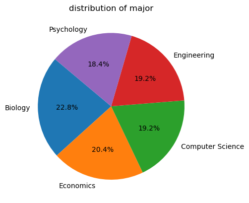

```python
# Write your code here
plt.pie(df['major'].value_counts(),labels=df['major'].value_counts().index,autopct ='%1.1f%%', startangle=140)
plt.title('distribution of major')
plt.show()
```

[5 points] Describe this visualization in your own words. What information does it convey?

อธิบายแผนภูมิที่สร้างขึ้น แผนภูมินี้สื่อถึงข้อมูลอะไร?

**ANS:** แสดงสัดส่วนจำนวนคนในคณะต่างๆ ประกอบด้วย Psychology :18.4%, Economics: 20.4%,Computer Science : 19.2%, Engineering : 19.2%, Biology 22.8%

##### 4.2 ศึกษาการกระจายตัวในข้อมูล (Total points = 24)

[7 points] Create a bar chart to demonstrate the distribution of gender. In your visualization, also display the chart title and data labels.

สร้างแผนภูมิแท่ง (bar chart) เพื่อแสดงการกระจายของเพศ (gender) ในการแสดงผล ให้แสดงชื่อแผนภูมิ และคำอธิบายสัญลักษณ์ (legend)

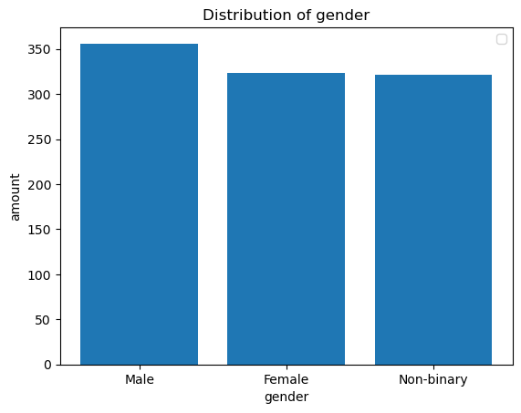

```python
# Write your code here
plt.figure()
plt.bar(df['gender'].value_counts().index,df['gender'].value_counts().values)
plt.title('Distribution of gender')
plt.xlabel('gender')
plt.ylabel("amount")
plt.legend()
plt.show()
```

[5 points] Describe this visualization in your own words. What information does it convey?

อธิบายแผนภูมิที่สร้างขึ้น แผนภูมินี้สื่อถึงข้อมูลอะไร?

**ANS:** จำนวนคนแต่ละเพศ ประกอบด้วย เพศ Male, Female, Non-binary ซึ่งจากแผนภูมิพบว่าเพศMale มากที่สุดและ Female, Non-binary มีจำนวนรองลงมากตามลำดับ

[7 points] Create a *horizontal* bar chart to demonstrate the distribution of year in school. In your visualization, also display the chart title and data labels.

สร้าง แผนภูมิแท่งแนวนอน (horizontal bar chart) เพื่อแสดงการกระจายของปีที่ศึกษา (year in school) ในการแสดงผล ให้แสดงชื่อแผนภูมิ และคำอธิบายสัญลักษณ์ (legend)

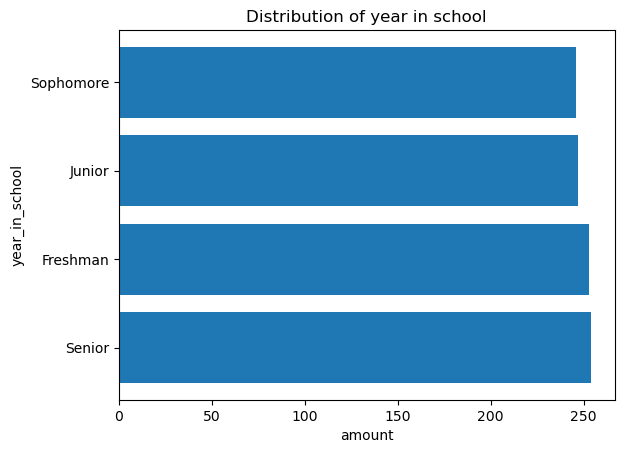

```python
# Write your code here
plt.figure()
plt.barh(df['year_in_school'].value_counts().index,df['year_in_school'].value_counts().values)
plt.title('Distribution of year in school')
plt.xlabel('amount')
plt.ylabel("year_in_school")
plt.show()
```

[5 points] Describe this visualization in your own words. What information does it convey?

อธิบายแผนภูมิที่สร้างขึ้น แผนภูมินี้สื่อถึงข้อมูลอะไร?

**ANS:** แสดงถึงจำนวนของนักศึกษาในแต่ละรุ่น ประกอบด้วย Senior, Freshman, Junior, Sophomor ซึ่งเรียงจากมากไปน้อยตามลำดับ

### Subtask #5: จัดกลุ่มข้อมูล

[6 points] Group the data by `year_in_school` and `major`, then display the sum of these attributes: `entertainment`, `personal_care`, `technology`, `health_wellness`, and `miscellaneous`.

จัดกลุ่มข้อมูลตาม `year_in_school` และ `major` แล้วแสดงผลรวมของคุณลักษณะต่อไปนี้: `entertainment`, `personal_care`, `technology`, `health_wellness`, และ `miscellaneous`

```python
# Write your code here
# Write your code here
df.groupby(['year_in_school','major'])[['entertainment','personal_care','technology','health_wellness','miscellaneous']].sum()
```

| year_in_school | major | entertainment | personal_care | technology | health_wellness | miscellaneous |
| --- | --- | --- | --- | --- | --- | --- |
| Freshman | Biology | 5173 | 3392 | 10912 | 7033 | 6240 |
|  | Computer Science | 4405 | 3300 | 9931 | 6069 | 5615 |
|  | Economics | 3832 | 2638 | 7530 | 4605 | 4143 |
|  | Engineering | 3844 | 3097 | 7838 | 5705 | 5105 |
|  | Psychology | 4536 | 3289 | 9551 | 5676 | 5292 |
| Junior | Biology | 5306 | 3562 | 9975 | 6997 | 6495 |
|  | Computer Science | 3886 | 2733 | 8375 | 5589 | 4938 |
|  | Economics | 3596 | 2689 | 9160 | 5231 | 5647 |
|  | Engineering | 4429 | 2802 | 9212 | 5122 | 4934 |
|  | Psychology | 3768 | 2602 | 7286 | 5564 | 4566 |
| Senior | Biology | 4557 | 3426 | 10858 | 6924 | 6193 |
|  | Computer Science | 3705 | 3164 | 7285 | 5406 | 5399 |
|  | Economics | 5166 | 3520 | 9589 | 6350 | 5787 |
|  | Engineering | 4188 | 3516 | 10223 | 5404 | 6325 |
|  | Psychology | 3498 | 2671 | 7783 | 5039 | 4610 |
| Sophomore | Biology | 4784 | 3053 | 9851 | 6778 | 6243 |
|  | Computer Science | 3770 | 2626 | 8200 | 5262 | 5359 |
|  | Economics | 4708 | 3158 | 10048 | 5612 | 6213 |
|  | Engineering | 3820 | 2404 | 6879 | 4373 | 4547 |
|  | Psychology | 3843 | 3057 | 7818 | 5571 | 5259 |

[2 points] Describe your understanding from this output.

อธิบายความเข้าใจจากผลลัพธ์ที่ได้

**ANS:** ภาพรวม entertainment, personal_care, technology,health_wellness,miscellaneous ในแต่ละคณะในแต่ละชั้นปี ทำให้สามารถทราบแนวโน้มพฤติกรรมและนำข้อมูลนี้ไปในการตัดสินได้